# Data Science for Public Policy

Assignment 04

Author

Asad & David

**Data Source:** [Statistical Performance Indicators by the World Bank](https://datacatalog.worldbank.org/search/dataset/0037996/Statistical-Performance-Indicators)

### The Statistical Performance Indicators (SPI) is a scoring frame developed by the World Bank to quantify data sources, availability and usage in countries. It includes area-wise scores, and an overall index.

## Pre-Work

### Packages

```r
library(tidyverse)
library(janitor)
library(purrr)
library(ggthemes)
```

### Data cleaning

```r
spi <- read.csv("data/spi.csv")


spi <- spi %>%
  select(country, iso3c, date, SPI.INDEX.PIL1, SPI.INDEX.PIL2, SPI.INDEX.PIL3,
         SPI.INDEX.PIL4, SPI.INDEX.PIL5, SPI.INDEX,
         income, region, population) %>%
  slice(-1)

spi <- spi %>%
  clean_names()

spi <- spi %>%
  mutate(spi_index_pil1 = as.numeric(spi_index_pil1))%>%
  mutate(spi_index_pil2 = as.numeric(spi_index_pil2))%>%
  mutate(spi_index_pil3 = as.numeric(spi_index_pil3))%>%
  mutate(spi_index_pil4 = as.numeric(spi_index_pil4))%>%
  mutate(spi_index_pil5 = as.numeric(spi_index_pil5))%>%
  mutate(spi_index = as.numeric(spi_index))

spi <- spi %>%
  mutate(spi_index = ifelse(spi_index == "", NA, spi_index))%>%
  mutate(country = ifelse(country == "", NA, country)) %>%
  mutate(iso3c = ifelse(iso3c == "", NA, iso3c))%>%
  mutate(date = ifelse(date == "", NA, date))%>%
  mutate(spi_index_pil1 = ifelse(spi_index_pil1 == "", NA, spi_index_pil1))%>%
  mutate(spi_index_pil2 = ifelse(spi_index_pil2 == "", NA, spi_index_pil2)) %>%
  mutate(spi_index_pil3 = ifelse(spi_index_pil3 == "", NA, spi_index_pil3))%>%
  mutate(spi_index_pil4 = ifelse(spi_index_pil4 == "", NA, spi_index_pil4))%>%
  mutate(spi_index_pil5 = ifelse(spi_index_pil5 == "", NA, spi_index_pil5))%>%
  mutate(income = ifelse(income == "", NA, income))%>%
  mutate(region = ifelse(region == "", NA, region))%>%
  mutate(population = ifelse(population == "", NA, population))
```

## Graph 1

#### This graph has two parts. The first shows a scatter plot by regions, comparing the countries’ SPI indexes over the global average (the dotted line). The second bar graph builds upon that by showing the number of countries in each region which are above the global average for 2022.

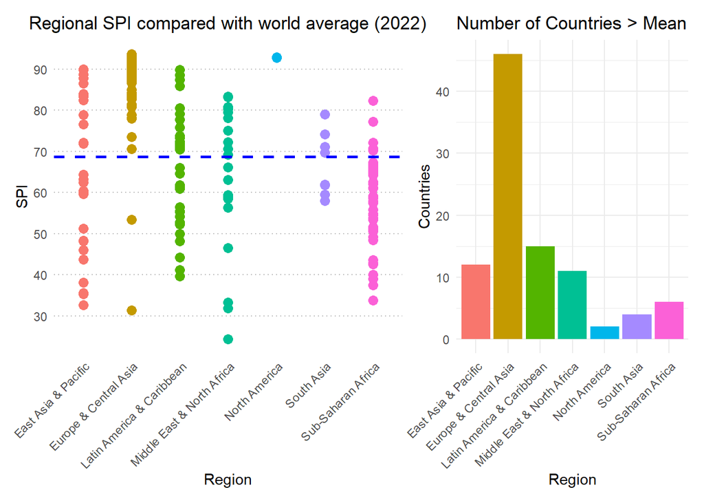

```r
library(patchwork)

spi_2022 <- spi %>%
  filter(date == 2022)

#creating variables of means to compare regional data with
overall_avg <- mean(spi_2022$spi_index, na.rm = TRUE)
obs_per_region <- tapply(spi_2022$spi_index > overall_avg, spi_2022$region, sum, na.rm = TRUE)

obs_df <- data.frame(region = names(obs_per_region), obs_count = obs_per_region)

scatter_plot <- ggplot(spi_2022, aes(x = region, y = spi_index, color = region)) +
  geom_point(position = position_jitter(width = 0), size = 3, show.legend = FALSE) +
  geom_hline(yintercept = overall_avg, linetype = "dashed", color = "blue", size = 1) +
  labs(title = "Regional SPI compared with world average (2022)",
       x = "Region",
       y = "SPI") +
  theme_minimal() +
  theme(axis.text.x = element_text(angle = 45, hjust = 1),
        plot.title = element_text(hjust = 0.5),
        panel.grid = element_blank(),
        panel.grid.major.y = element_line(color = "gray", linetype = "dotted")) +
  scale_y_continuous(breaks = seq(0, max(spi_2022$spi_index, na.rm = TRUE) + 10, by = 10))

bar_graph <- ggplot(obs_df, aes(x = region, y = obs_count, fill = region)) +
  geom_bar(stat = "identity", show.legend = FALSE) +
  labs(title = "Number of Countries > Mean",
       x = "Region",
       y = "Countries") +
  theme_minimal() +
  theme(axis.text.x = element_text(angle = 45, hjust = 1))


scatter_plot + bar_graph + plot_layout(ncol = 2, widths = c(3, 2))
```

## Graph 2

#### The Statistical Performance Index is comprised of 5 pillars. With this plot we want to understand the performance of each region of the world in each pillar of the Index. Additionally, we can see the global mean for each pillar to see the relative stand of each region.

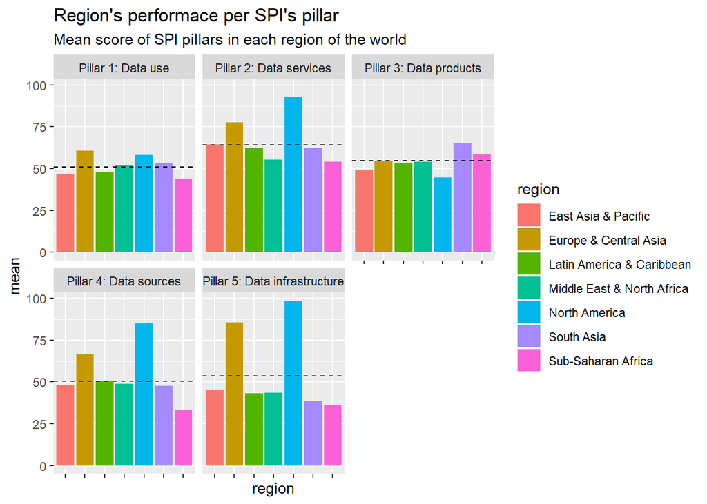

```r
#Setting the dataframe longer to have the number of pillar as one varibale and the scores of those pillars as a second variable.
spi_pillars <- spi %>%
  select(country, spi_index_pil1,
         spi_index_pil2, spi_index_pil3,
         spi_index_pil4, spi_index_pil5,
         region)%>%
  pivot_longer(cols = c(spi_index_pil1, spi_index_pil2,
                        spi_index_pil3, spi_index_pil4,
                        spi_index_pil5),
               names_to = "pillars_num",
               values_to = "pillar_score")

#Creating an object containing the names we want to appear in the plot for each pillar.
pillars_name <- c("spi_index_pil1" = "Pillar 1: Data use",
                  "spi_index_pil2" = "Pillar 2: Data services",
                  "spi_index_pil3" = "Pillar 3: Data products",
                  "spi_index_pil4" = "Pillar 4: Data sources",
                  "spi_index_pil5" = "Pillar 5: Data infrastructure")

#Creating an object that contains the global mean for each pillar. We want this to appear in the plot for each pilar.
mean_pillars <- spi_pillars %>%
  group_by(pillars_num) %>%
  summarise(overall_mean = mean(pillar_score, na.rm = TRUE))

spi_pillars %>%
  group_by(pillars_num, region)%>%
  summarise(mean = mean(pillar_score, na.rm = TRUE))%>%
  ggplot()+
  geom_col(aes(x = region, y = mean, fill = region))+
  geom_hline(data = mean_pillars, aes(yintercept = overall_mean), linetype = "dashed", color = "black")+
  facet_wrap(~ pillars_num, labeller = as_labeller(pillars_name))+
   labs(title = "Region's performace per SPI's pillar", subtitle = "Mean score of SPI pillars in each region of the world")+
  theme(axis.text.x = element_blank())
```

## Graph 3

#### With this plot we want to observe how the global Statitical Performance Indicator score for each region has changed over time.

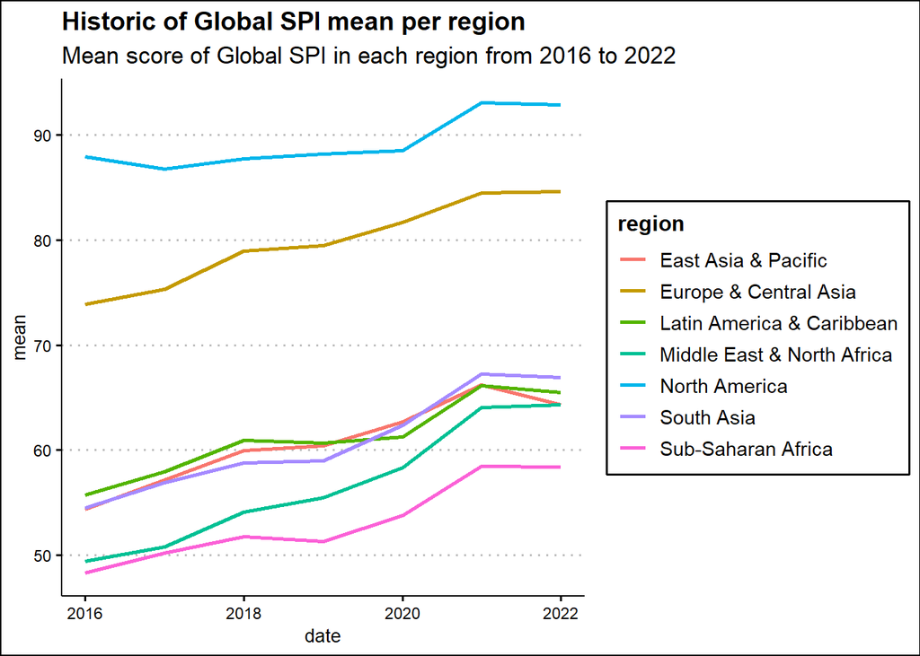

```r
spi_time <- spi %>%
  select(country, spi_index,region,date)


spi_time %>%
  filter(date %in% 2016:2022)%>%
  group_by(date, region)%>%
  summarize(mean = mean(spi_index, na.rm = TRUE))%>%
  ggplot()+
  geom_line(aes(x = date,
                y = mean,
                group = region,
                color = region),
            linewidth = 1)+
  labs(title = "Historic of Global SPI mean per region",
       subtitle = "Mean score of Global SPI in each region from 2016 to 2022")+
  theme_clean()
```

## Graph 4

#### This graph shows the trend of SPI as per the population of the respective countries. The line of best fit added shows a positive correlation between the two.

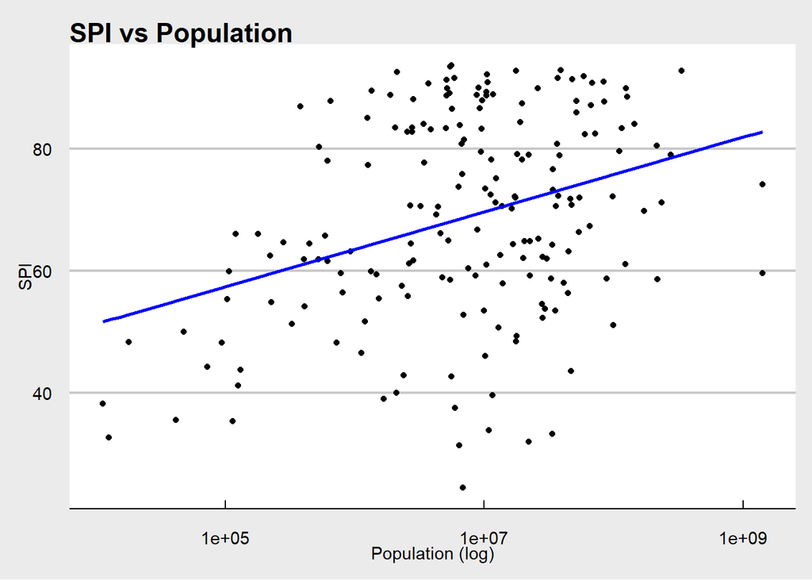

```r
ggplot(spi_2022, aes(x = population, y = spi_index)) +
  geom_point() +
  geom_smooth(method = "lm", se = FALSE, color = "blue") +  # Add a line of best fit
  labs(title = "SPI vs Population",
       x = "Population (log)",
       y = "SPI") +
  scale_x_log10() +
  theme_economist_white()
```